# Shuisky_project

```python
import numpy as np
import pandas as pd
import scipy.stats as sts
import matplotlib.pyplot as plt
import seaborn as sns
from sklearn.model_selection import train_test_split
from sklearn.linear_model import LogisticRegression
from sklearn import metrics
from sklearn.metrics import roc_curve, auc
from sklearn.metrics import confusion_matrix
from sklearn.pipeline import Pipeline
from sklearn.preprocessing import StandardScaler
from sklearn.model_selection import GridSearchCV
from sklearn.model_selection import KFold
from sklearn.model_selection import cross_val_score
from sklearn.metrics import roc_auc_score
from sklearn.linear_model import LogisticRegression
from sklearn.discriminant_analysis import LinearDiscriminantAnalysis
from sklearn.neighbors import KNeighborsClassifier
from sklearn.tree import DecisionTreeClassifier
from sklearn.svm import SVC
from xgboost import XGBClassifier
from sklearn.ensemble import RandomForestClassifier
from sklearn.model_selection import RandomizedSearchCV
import warnings
warnings.filterwarnings("ignore")
```

```python
FromDate_1 = "01.01.2003"
ToDate_1 = "01.01.2013"
str_1 = 'http://www.cbr.ru/hd_base/zcyc_params/?UniDbQuery.Posted=True&UniDbQuery.From='
str_2 = '&UniDbQuery.To='
str_3_1 = str_1 + FromDate_1 + str_2 + ToDate_1
table_1 =  pd.read_html(str_3_1, decimal = ',')
df_1 = table_1[0]
new_columns= ([el[1].replace(',', '.') for el in df_1.columns])
df_1.set_axis(new_columns, axis=1, inplace=True)
FromDate_2 = "01.01.2013"
ToDate_2 = "01.05.2023"
str_3_2 = str_1 + FromDate_2 + str_2 + ToDate_2
table_2 =  pd.read_html(str_3_2, decimal = ',')
df_2 = table_2[0]
new_columns= ([el[1].replace(',', '.') for el in df_2.columns])
df_2.set_axis(new_columns, axis=1, inplace=True)
```

```python
df = pd.merge(df_1, df_2, how = 'outer')
df
```

|  | Дата | 0.25 | 0.5 | 0.75 | 1 | 2 | 3 | 5 | 7 | 10 | 15 | 20 | 30 |
| --- | --- | --- | --- | --- | --- | --- | --- | --- | --- | --- | --- | --- | --- |
| 0 | 28.12.2012 | 608 | 614 | 619 | 623 | 632 | 636 | 653 | 674 | 702 | 738 | 771 | 834 |
| 1 | 27.12.2012 | 612 | 617 | 620 | 623 | 629 | 634 | 654 | 676 | 704 | 740 | 775 | 843 |
| 2 | 26.12.2012 | 618 | 620 | 623 | 625 | 631 | 633 | 652 | 676 | 705 | 740 | 773 | 841 |
| 3 | 25.12.2012 | 615 | 617 | 619 | 621 | 628 | 634 | 654 | 676 | 705 | 742 | 777 | 846 |
| 4 | 24.12.2012 | 619 | 622 | 625 | 627 | 631 | 633 | 652 | 678 | 708 | 743 | 774 | 838 |
| ... | ... | ... | ... | ... | ... | ... | ... | ... | ... | ... | ... | ... | ... |
| 5151 | 14.01.2013 | 586 | 591 | 595 | 597 | 601 | 602 | 620 | 644 | 679 | 724 | 762 | 830 |
| 5152 | 11.01.2013 | 590 | 595 | 598 | 601 | 603 | 605 | 623 | 647 | 682 | 727 | 764 | 829 |
| 5153 | 10.01.2013 | 596 | 600 | 603 | 605 | 604 | 599 | 612 | 636 | 669 | 710 | 753 | 841 |
| 5154 | 09.01.2013 | 583 | 592 | 601 | 608 | 625 | 631 | 642 | 656 | 680 | 718 | 755 | 822 |
| 5155 | 08.01.2013 | 612 | 618 | 623 | 627 | 634 | 638 | 656 | 678 | 706 | 742 | 775 | 837 |

5156 rows × 13 columns

```python
for col in df.columns[1:]:
    df[col] = df[col].map(lambda x: x / 100)
df["Дата"] = pd.to_datetime(df["Дата"],format = '%d.%m.%Y')
df = df.sort_values(by="Дата")
df = df.set_index('Дата')
df
```

| Дата | 0.25 | 0.5 | 0.75 | 1 | 2 | 3 | 5 | 7 | 10 | 15 | 20 | 30 |
| --- | --- | --- | --- | --- | --- | --- | --- | --- | --- | --- | --- | --- |
| 2003-01-04 | 11.68 | 12.31 | 12.76 | 13.08 | 13.63 | 13.72 | 13.63 | 13.53 | 13.45 | 13.38 | 13.35 | 13.32 |
| 2003-01-05 | 11.09 | 11.70 | 12.16 | 12.50 | 13.14 | 13.30 | 13.31 | 13.27 | 13.23 | 13.20 | 13.19 | 13.17 |
| 2003-01-08 | 10.84 | 11.61 | 12.15 | 12.53 | 13.18 | 13.30 | 13.29 | 13.24 | 13.19 | 13.15 | 13.13 | 13.11 |
| 2003-01-09 | 10.46 | 11.13 | 11.67 | 12.09 | 13.02 | 13.31 | 13.38 | 13.32 | 13.25 | 13.19 | 13.16 | 13.13 |
| 2003-01-10 | 10.10 | 11.08 | 11.79 | 12.28 | 13.14 | 13.31 | 13.27 | 13.19 | 13.11 | 13.04 | 13.00 | 12.97 |
| ... | ... | ... | ... | ... | ... | ... | ... | ... | ... | ... | ... | ... |
| 2023-04-24 | 7.25 | 7.25 | 7.31 | 7.41 | 8.01 | 8.66 | 9.73 | 10.42 | 10.97 | 11.37 | 11.57 | 11.79 |
| 2023-04-25 | 7.20 | 7.20 | 7.26 | 7.36 | 7.96 | 8.60 | 9.69 | 10.40 | 11.00 | 11.44 | 11.64 | 11.88 |
| 2023-04-26 | 7.29 | 7.31 | 7.37 | 7.46 | 8.00 | 8.60 | 9.66 | 10.39 | 11.01 | 11.48 | 11.71 | 11.97 |
| 2023-04-27 | 7.18 | 7.19 | 7.25 | 7.35 | 7.92 | 8.56 | 9.65 | 10.38 | 10.99 | 11.44 | 11.65 | 11.90 |
| 2023-04-28 | 7.23 | 7.26 | 7.33 | 7.44 | 7.98 | 8.58 | 9.61 | 10.33 | 10.93 | 11.37 | 11.59 | 11.85 |

5156 rows × 12 columns

```python
columns = ['0.25', '0.5', '0.75', '1', '2', '3', '5', '7', '10', '15', '20', '30']
df[columns] = df[columns].astype(float)
```

```python
df.info()
```

```
<class 'pandas.core.frame.DataFrame'>
DatetimeIndex: 5156 entries, 2003-01-04 to 2023-04-28
Data columns (total 12 columns):
 #   Column  Non-Null Count  Dtype
---  ------  --------------  -----
 0   0.25    5156 non-null   float64
 1   0.5     5156 non-null   float64
 2   0.75    5156 non-null   float64
 3   1       5156 non-null   float64
 4   2       5156 non-null   float64
 5   3       5156 non-null   float64
 6   5       5156 non-null   float64
 7   7       5156 non-null   float64
 8   10      5156 non-null   float64
 9   15      5156 non-null   float64
 10  20      5156 non-null   float64
 11  30      5156 non-null   float64
dtypes: float64(12)
memory usage: 523.7 KB
```

##### Провели первичную обработку данных, а именно преобразовали в необходимые типы данных, проверили на наличие пропусков, дату сделали индексом

##### У нас каждой дате соотвествуют доходности облигаций с различным сроком до погашения на конец определенного дня

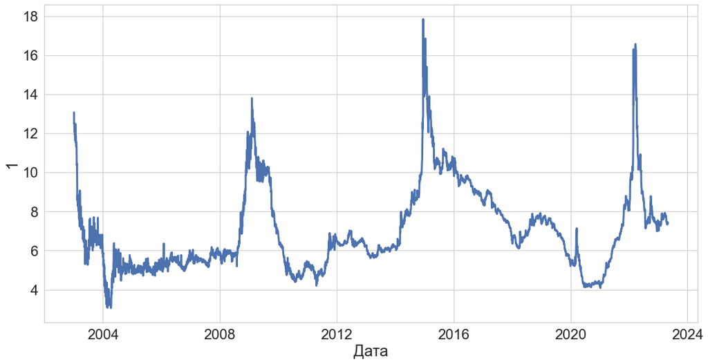

```python
fig = plt.subplots(figsize=(18, 9))
sns.lineplot(data = df['1'], lw=3);
```

##### На графике мы видим, что КБД для облигаций, срок погашения которых 1 год, очень отчетливо показывает 3 кризиса в России: 2008-2010, 2014-2015 и 2020 - по настоящее время. Возможно последний следует разделять на кризиз 2020 года и кризис 2022 - по настоящее время. Получается, что КБД дейтсвительно может служить определенным индикатором кризиса, однако неясно, является ли он запаздыващим или наоборот опережающим.

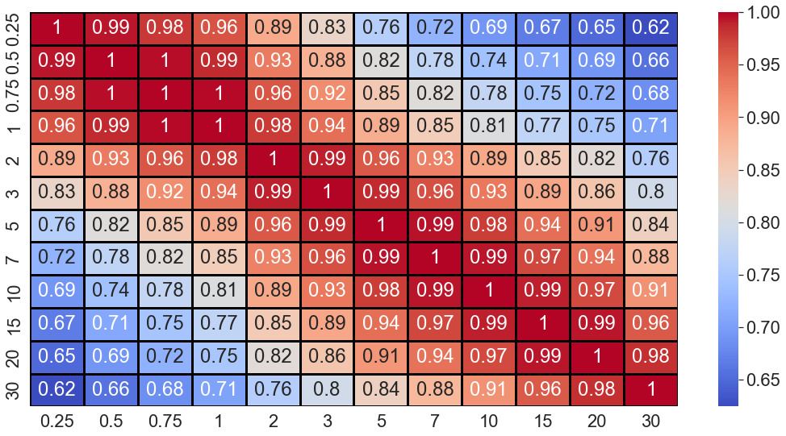

```python
fig = plt.subplots(figsize=(18, 9))
sns.heatmap(df.corr(), annot = True, cmap= 'coolwarm', linewidths=3, linecolor='black');
```

##### Можно заметить, что взаимосвязь между данными очень тесная и положительная. Даже самые далекие друг от друга по погашению облигации показывают одностороннюю взаимосвязь порядка 62%

```python
df.describe()
```

|  | 0.25 | 0.5 | 0.75 | 1 | 2 | 3 | 5 | 7 | 10 | 15 | 20 | 30 |
| --- | --- | --- | --- | --- | --- | --- | --- | --- | --- | --- | --- | --- |
| count | 5156.000000 | 5156.000000 | 5156.000000 | 5156.000000 | 5156.000000 | 5156.000000 | 5156.000000 | 5156.000000 | 5156.000000 | 5156.000000 | 5156.000000 | 5156.000000 |
| mean | 6.411195 | 6.623592 | 6.804484 | 6.960229 | 7.410753 | 7.687671 | 7.999922 | 8.167244 | 8.313095 | 8.446394 | 8.525803 | 8.621261 |
| std | 2.323978 | 2.213181 | 2.136834 | 2.080147 | 1.947814 | 1.865319 | 1.739069 | 1.640463 | 1.533024 | 1.423267 | 1.362541 | 1.316615 |
| min | 1.690000 | 2.150000 | 2.600000 | 3.050000 | 4.240000 | 4.600000 | 4.950000 | 5.220000 | 5.590000 | 5.970000 | 6.170000 | 6.370000 |
| 25% | 4.597500 | 4.920000 | 5.200000 | 5.430000 | 6.060000 | 6.440000 | 6.800000 | 6.990000 | 7.197500 | 7.460000 | 7.630000 | 7.727500 |
| 50% | 6.000000 | 6.120000 | 6.250000 | 6.400000 | 6.800000 | 7.110000 | 7.650000 | 7.930000 | 8.130000 | 8.320000 | 8.410000 | 8.600000 |
| 75% | 7.640000 | 7.710000 | 7.830000 | 7.920000 | 8.200000 | 8.410000 | 8.610000 | 8.720000 | 8.840000 | 9.000000 | 9.070000 | 9.120000 |
| max | 17.870000 | 17.560000 | 17.690000 | 17.860000 | 18.450000 | 18.520000 | 17.720000 | 16.760000 | 15.830000 | 15.150000 | 14.890000 | 14.650000 |

##### Немного описательной статистики, которая дает немного представления в целом о собранных данных

##### Наше исследование будет построено на основе научной работы:

##### Болдырева Н. Б., Парфенов А. А. Ранняя диагностика кризисных явлений на фондовом рынке //Деньги и кредит. – 2015. – №. 8. – С. 71-74.

##### https://elibrary.ru/ucpjux

##### Именно исходя из методологии этой статьи и приведенным в ней выводам мы будем определять, действительно ли в какой-то момент начался кризис

##### Давайте создадим такие признаки, как наклон и изгиб прямой

```python
df_sc = df.copy()
df_sc['Slope'] = df_sc['10']-df_sc['1'] # наклон
df_sc['Curvature'] = df_sc['5']-(df_sc['1']+df_sc['10'])/2 # изгиб
df_sc
```

| Дата | 0.25 | 0.5 | 0.75 | 1 | 2 | 3 | 5 | 7 | 10 | 15 | 20 | 30 | Slope | Curvature |
| --- | --- | --- | --- | --- | --- | --- | --- | --- | --- | --- | --- | --- | --- | --- |
| 2003-01-04 | 11.68 | 12.31 | 12.76 | 13.08 | 13.63 | 13.72 | 13.63 | 13.53 | 13.45 | 13.38 | 13.35 | 13.32 | 0.37 | 0.365 |
| 2003-01-05 | 11.09 | 11.70 | 12.16 | 12.50 | 13.14 | 13.30 | 13.31 | 13.27 | 13.23 | 13.20 | 13.19 | 13.17 | 0.73 | 0.445 |
| 2003-01-08 | 10.84 | 11.61 | 12.15 | 12.53 | 13.18 | 13.30 | 13.29 | 13.24 | 13.19 | 13.15 | 13.13 | 13.11 | 0.66 | 0.430 |
| 2003-01-09 | 10.46 | 11.13 | 11.67 | 12.09 | 13.02 | 13.31 | 13.38 | 13.32 | 13.25 | 13.19 | 13.16 | 13.13 | 1.16 | 0.710 |
| 2003-01-10 | 10.10 | 11.08 | 11.79 | 12.28 | 13.14 | 13.31 | 13.27 | 13.19 | 13.11 | 13.04 | 13.00 | 12.97 | 0.83 | 0.575 |
| ... | ... | ... | ... | ... | ... | ... | ... | ... | ... | ... | ... | ... | ... | ... |
| 2023-04-24 | 7.25 | 7.25 | 7.31 | 7.41 | 8.01 | 8.66 | 9.73 | 10.42 | 10.97 | 11.37 | 11.57 | 11.79 | 3.56 | 0.540 |
| 2023-04-25 | 7.20 | 7.20 | 7.26 | 7.36 | 7.96 | 8.60 | 9.69 | 10.40 | 11.00 | 11.44 | 11.64 | 11.88 | 3.64 | 0.510 |
| 2023-04-26 | 7.29 | 7.31 | 7.37 | 7.46 | 8.00 | 8.60 | 9.66 | 10.39 | 11.01 | 11.48 | 11.71 | 11.97 | 3.55 | 0.425 |
| 2023-04-27 | 7.18 | 7.19 | 7.25 | 7.35 | 7.92 | 8.56 | 9.65 | 10.38 | 10.99 | 11.44 | 11.65 | 11.90 | 3.64 | 0.480 |
| 2023-04-28 | 7.23 | 7.26 | 7.33 | 7.44 | 7.98 | 8.58 | 9.61 | 10.33 | 10.93 | 11.37 | 11.59 | 11.85 | 3.49 | 0.425 |

5156 rows × 14 columns

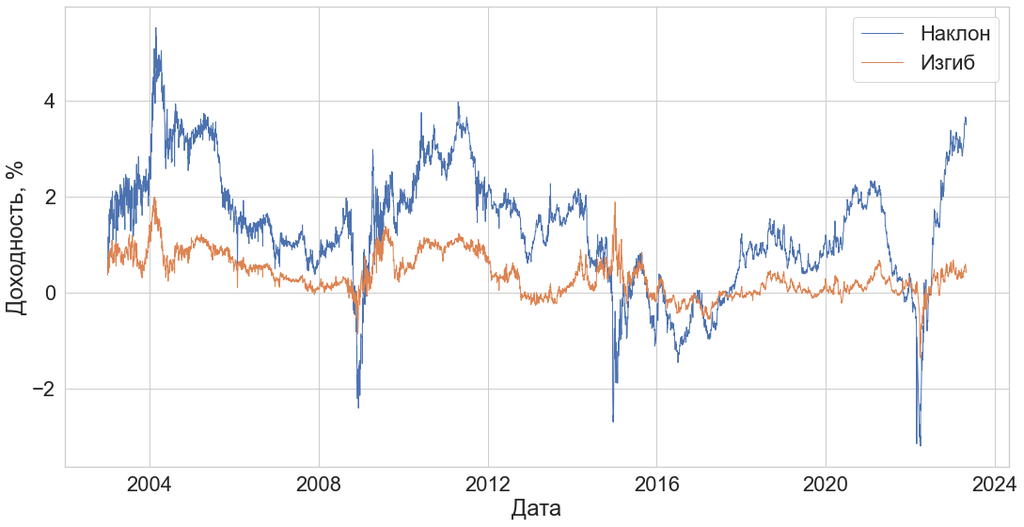

```python
fig = plt.subplots(figsize = (18, 9));
sns.lineplot(data = df_sc['Slope'], lw = 1, label = 'Наклон')
sns.lineplot(data = df_sc['Curvature'], lw = 1, label = 'Изгиб')
plt.ylabel('Доходность, %');
```

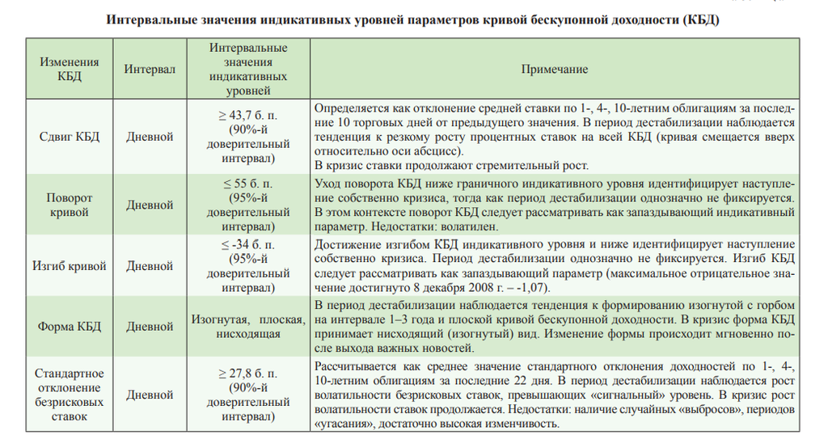

##### Создадим 2 доп. выборки - период роста экономики (2005-2008) и период кризиса (2008-2010), именно эти даты были выбраны на основании статьи

```python
df_chill = df.loc[(df.index >= '2005-09-01') & (df.index <= '2008-07-31')].sort_index(ascending=True)
```

```python
df_crisis = df.loc[(df.index >= '2008-08-01') & (df.index <= '2010-09-30')].sort_index(ascending=True)
```

```python
print(f'Средняя доходность 1-летней облигации за все время наблюдений {round(df["1"].mean(),2)}' )
print(f'Средняя доходность 1-летней облигации за период роста {round(df_chill["1"].mean(),2)}' )
print(f'Средняя доходность 1-летней облигации за период кризиса {round(df_crisis["1"].mean(),2)}' )
print(f'Средняя доходность 5-летней облигации за все время наблюдений {round(df["5"].mean(),2)}' )
print(f'Средняя доходность 5-летней облигации за период роста {round(df_chill["5"].mean(),2)}' )
print(f'Средняя доходность 5-летней облигации за период кризиса {round(df_crisis["5"].mean(),2)}' )
print(f'Средняя доходность 10-летней облигации за все время наблюдений {round(df["10"].mean(),2)}' )
print(f'Средняя доходность 10-летней облигации за период роста {round(df_chill["10"].mean(),2)}' )
print(f'Средняя доходность 10-летней облигации за период кризиса {round(df_crisis["10"].mean(),2)}' )
```

```
Средняя доходность 1-летней облигации за все время наблюдений 6.96
Средняя доходность 1-летней облигации за период роста 5.51
Средняя доходность 1-летней облигации за период кризиса 7.93
Средняя доходность 5-летней облигации за все время наблюдений 8.0
Средняя доходность 5-летней облигации за период роста 6.49
Средняя доходность 5-летней облигации за период кризиса 9.33
Средняя доходность 10-летней облигации за все время наблюдений 8.31
Средняя доходность 10-летней облигации за период роста 6.72
Средняя доходность 10-летней облигации за период кризиса 9.53
```

##### Видим, что ставки растут в период кризисов, а в перод роста наоборот падают. Все это сочетается с экономической теорией

```python
print(f'Средняя доходность 1-летней облигации за все время наблюдений {round(df["1"].std(),2)}' )
print(f'Средняя доходность 1-летней облигации за период роста {round(df_chill["1"].std(),2)}' )
print(f'Средняя доходность 1-летней облигации за период кризиса {round(df_crisis["1"].std(),2)}' )
print(f'Средняя доходность 5-летней облигации за все время наблюдений {round(df["5"].std(),2)}' )
print(f'Средняя доходность 5-летней облигации за период роста {round(df_chill["5"].std(),2)}' )
print(f'Средняя доходность 5-летней облигации за период кризиса {round(df_crisis["5"].std(),2)}' )
print(f'Средняя доходность 10-летней облигации за все время наблюдений {round(df["10"].std(),2)}' )
print(f'Средняя доходность 10-летней облигации за период роста {round(df_chill["10"].std(),2)}' )
print(f'Средняя доходность 10-летней облигации за период кризиса {round(df_crisis["10"].std(),2)}' )
```

```
Средняя доходность 1-летней облигации за все время наблюдений 2.08
Средняя доходность 1-летней облигации за период роста 0.31
Средняя доходность 1-летней облигации за период кризиса 2.51
Средняя доходность 5-летней облигации за все время наблюдений 1.74
Средняя доходность 5-летней облигации за период роста 0.22
Средняя доходность 5-летней облигации за период кризиса 2.14
Средняя доходность 10-летней облигации за все время наблюдений 1.53
Средняя доходность 10-летней облигации за период роста 0.21
Средняя доходность 10-летней облигации за период кризиса 1.9
```

##### Также в кризисные периоды повышается волатильность ставок, причем чем больше срок до погашения, тем волатильность меньше

##### Чтобы детальнее рассмотреть как это проиходит, рассмотрим промежуток с мая по ноябрь 2008 года

```python
df_demo = df.loc[(df.index >= '2008-05-01') & (df.index <= '2008-10-31')].sort_index(ascending=True)
```

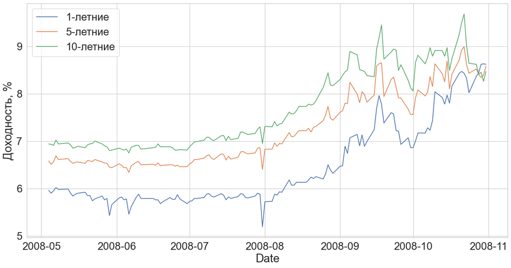

```python
fig = plt.subplots(figsize=(18, 9))
sns.lineplot(data = df_demo['1'], label = '1-летние')
sns.lineplot(data = df_demo['5'], label = '5-летние')
sns.lineplot(data = df_demo['10'], label = '10-летние')
plt.ylabel('Доходность, %');
```

##### Начиная с августа, ставки начали расти на ожиданиях рынка касательно будущего и возможного кризиса, а уже в сентябре можно точно сказать, что кризис начался

```python
df
```

| Дата | 0.25 | 0.5 | 0.75 | 1 | 2 | 3 | 5 | 7 | 10 | 15 | 20 | 30 |
| --- | --- | --- | --- | --- | --- | --- | --- | --- | --- | --- | --- | --- |
| 2003-01-04 | 11.68 | 12.31 | 12.76 | 13.08 | 13.63 | 13.72 | 13.63 | 13.53 | 13.45 | 13.38 | 13.35 | 13.32 |
| 2003-01-05 | 11.09 | 11.70 | 12.16 | 12.50 | 13.14 | 13.30 | 13.31 | 13.27 | 13.23 | 13.20 | 13.19 | 13.17 |
| 2003-01-08 | 10.84 | 11.61 | 12.15 | 12.53 | 13.18 | 13.30 | 13.29 | 13.24 | 13.19 | 13.15 | 13.13 | 13.11 |
| 2003-01-09 | 10.46 | 11.13 | 11.67 | 12.09 | 13.02 | 13.31 | 13.38 | 13.32 | 13.25 | 13.19 | 13.16 | 13.13 |
| 2003-01-10 | 10.10 | 11.08 | 11.79 | 12.28 | 13.14 | 13.31 | 13.27 | 13.19 | 13.11 | 13.04 | 13.00 | 12.97 |
| ... | ... | ... | ... | ... | ... | ... | ... | ... | ... | ... | ... | ... |
| 2023-04-24 | 7.25 | 7.25 | 7.31 | 7.41 | 8.01 | 8.66 | 9.73 | 10.42 | 10.97 | 11.37 | 11.57 | 11.79 |
| 2023-04-25 | 7.20 | 7.20 | 7.26 | 7.36 | 7.96 | 8.60 | 9.69 | 10.40 | 11.00 | 11.44 | 11.64 | 11.88 |
| 2023-04-26 | 7.29 | 7.31 | 7.37 | 7.46 | 8.00 | 8.60 | 9.66 | 10.39 | 11.01 | 11.48 | 11.71 | 11.97 |
| 2023-04-27 | 7.18 | 7.19 | 7.25 | 7.35 | 7.92 | 8.56 | 9.65 | 10.38 | 10.99 | 11.44 | 11.65 | 11.90 |
| 2023-04-28 | 7.23 | 7.26 | 7.33 | 7.44 | 7.98 | 8.58 | 9.61 | 10.33 | 10.93 | 11.37 | 11.59 | 11.85 |

5156 rows × 12 columns

##### Однако исходя из статьи, наклон и изгиб КБД - запаздывающие индикаторы, которые не подходят для нашего исследования. Наша цель - научиться определять кризис заранее. Для этого воспользуемся таким индикатором как стандартное отклонение безрисковых ставок. В научной статье его выделяют как опережающий индикатор (опережение составляет примерно полмесяца - месяц)

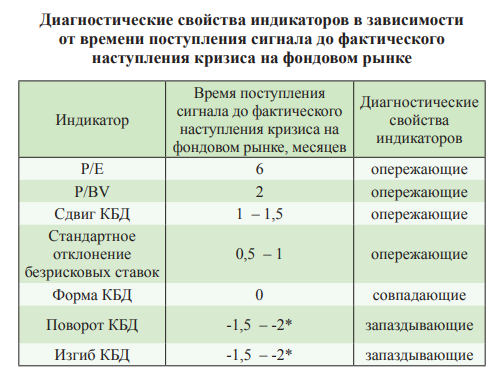

```python
df['std'] = (df['1'].rolling(window = 22).std()+df['5'].rolling(window = 22).std()+df['10'].rolling(window = 22).std())/3
```

```python
df['std'].fillna(0)
```

```
Дата
2003-01-04    0.000000
2003-01-05    0.000000
2003-01-08    0.000000
2003-01-09    0.000000
2003-01-10    0.000000
                ...
2023-04-24    0.109650
2023-04-25    0.107425
2023-04-26    0.103418
2023-04-27    0.100212
2023-04-28    0.095812
Name: std, Length: 5156, dtype: float64
```

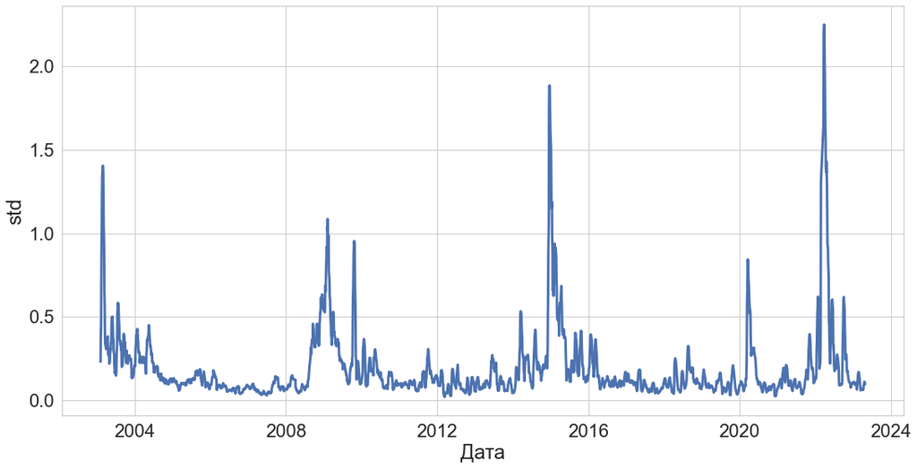

```python
fig = plt.subplots(figsize=(18, 9))
sns.lineplot(data = df['std'], lw=3);
```

##### Опять же все согласуется с теорией и статьей. Слишком высокие показатели стандартного отклонения сведительствуют о большой волатильности и означают скорее период неопределенности, за которым обычно и следует кризис

##### Давайте создадим индикатор, который показывает, превышает ли стандартное отклонение индикативный уровень, представленный в статье. В данном случае будем рассматривать 1 как показать потенциального кризиса и 0 как отсутствие кризиса

```python
df['indicator'] = np.where(df['std']>0.278, 1, 0)
```

```python
df
```

| Дата | 0.25 | 0.5 | 0.75 | 1 | 2 | 3 | 5 | 7 | 10 | 15 | 20 | 30 | std | indicator |
| --- | --- | --- | --- | --- | --- | --- | --- | --- | --- | --- | --- | --- | --- | --- |
| 2003-01-04 | 11.68 | 12.31 | 12.76 | 13.08 | 13.63 | 13.72 | 13.63 | 13.53 | 13.45 | 13.38 | 13.35 | 13.32 | NaN | 0 |
| 2003-01-05 | 11.09 | 11.70 | 12.16 | 12.50 | 13.14 | 13.30 | 13.31 | 13.27 | 13.23 | 13.20 | 13.19 | 13.17 | NaN | 0 |
| 2003-01-08 | 10.84 | 11.61 | 12.15 | 12.53 | 13.18 | 13.30 | 13.29 | 13.24 | 13.19 | 13.15 | 13.13 | 13.11 | NaN | 0 |
| 2003-01-09 | 10.46 | 11.13 | 11.67 | 12.09 | 13.02 | 13.31 | 13.38 | 13.32 | 13.25 | 13.19 | 13.16 | 13.13 | NaN | 0 |
| 2003-01-10 | 10.10 | 11.08 | 11.79 | 12.28 | 13.14 | 13.31 | 13.27 | 13.19 | 13.11 | 13.04 | 13.00 | 12.97 | NaN | 0 |
| ... | ... | ... | ... | ... | ... | ... | ... | ... | ... | ... | ... | ... | ... | ... |
| 2023-04-24 | 7.25 | 7.25 | 7.31 | 7.41 | 8.01 | 8.66 | 9.73 | 10.42 | 10.97 | 11.37 | 11.57 | 11.79 | 0.109650 | 0 |
| 2023-04-25 | 7.20 | 7.20 | 7.26 | 7.36 | 7.96 | 8.60 | 9.69 | 10.40 | 11.00 | 11.44 | 11.64 | 11.88 | 0.107425 | 0 |
| 2023-04-26 | 7.29 | 7.31 | 7.37 | 7.46 | 8.00 | 8.60 | 9.66 | 10.39 | 11.01 | 11.48 | 11.71 | 11.97 | 0.103418 | 0 |
| 2023-04-27 | 7.18 | 7.19 | 7.25 | 7.35 | 7.92 | 8.56 | 9.65 | 10.38 | 10.99 | 11.44 | 11.65 | 11.90 | 0.100212 | 0 |
| 2023-04-28 | 7.23 | 7.26 | 7.33 | 7.44 | 7.98 | 8.58 | 9.61 | 10.33 | 10.93 | 11.37 | 11.59 | 11.85 | 0.095812 | 0 |

5156 rows × 14 columns

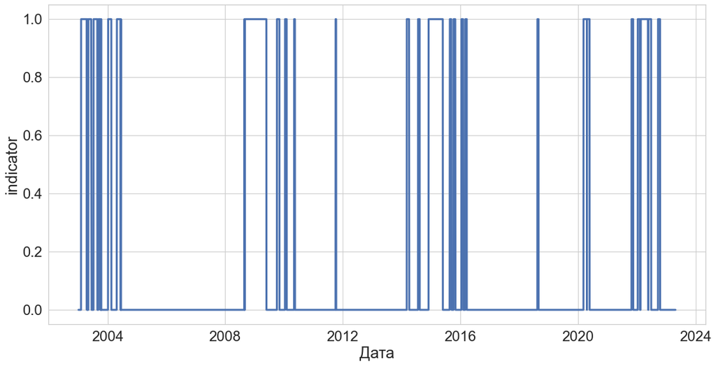

```python
fig = plt.subplots(figsize=(18, 9))
sns.lineplot(data = df['indicator'], lw=3);
```

##### Наверное лучше всего будет показать значение индикатора на выборке май-ноябрь 2008 г.

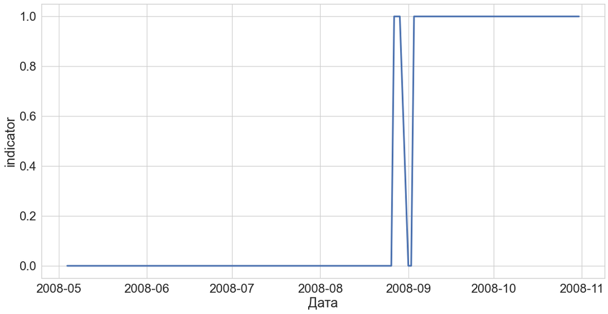

```python
df_demo_2 = df.loc[(df.index >= '2008-05-01') & (df.index <= '2008-10-31')].sort_index(ascending=True)
fig = plt.subplots(figsize=(18, 9))
sns.lineplot(data = df_demo_2['indicator'], lw=3);
```

##### Рассмотрим покрупнее

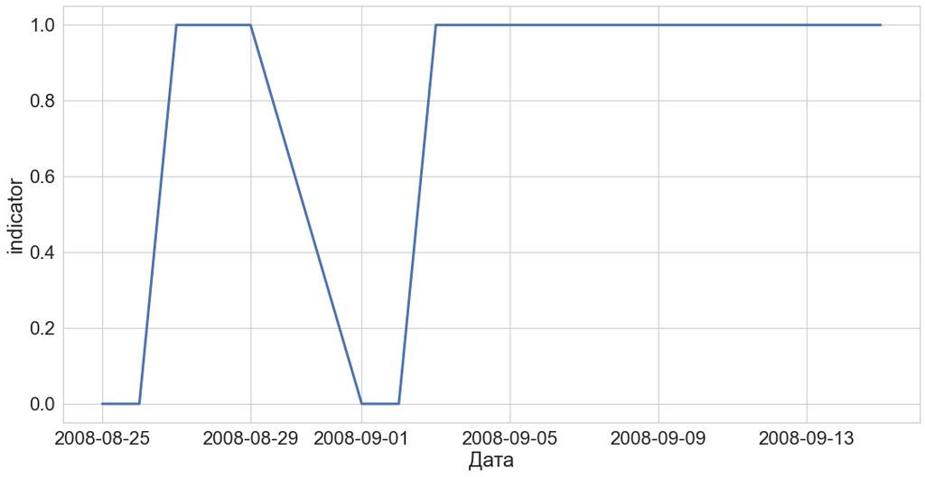

```python
df_demo_3 = df.loc[(df.index >= '2008-08-23') & (df.index <= '2008-09-15')].sort_index(ascending=True)
fig = plt.subplots(figsize=(18, 9))
sns.lineplot(data = df_demo_3['indicator'], lw=3);
```

##### Видим, что кризис по методологии из статьи уже был очевиден в конце августа, а также в начале сентября

```python
df_base = df.drop('std', axis = 1)
```

##### Создадим дальше базовую таблицу, с которой будем работать дальше на протяжении всего исследования

```python
df_base
```

| Дата | 0.25 | 0.5 | 0.75 | 1 | 2 | 3 | 5 | 7 | 10 | 15 | 20 | 30 | indicator |
| --- | --- | --- | --- | --- | --- | --- | --- | --- | --- | --- | --- | --- | --- |
| 2003-01-04 | 11.68 | 12.31 | 12.76 | 13.08 | 13.63 | 13.72 | 13.63 | 13.53 | 13.45 | 13.38 | 13.35 | 13.32 | 0 |
| 2003-01-05 | 11.09 | 11.70 | 12.16 | 12.50 | 13.14 | 13.30 | 13.31 | 13.27 | 13.23 | 13.20 | 13.19 | 13.17 | 0 |
| 2003-01-08 | 10.84 | 11.61 | 12.15 | 12.53 | 13.18 | 13.30 | 13.29 | 13.24 | 13.19 | 13.15 | 13.13 | 13.11 | 0 |
| 2003-01-09 | 10.46 | 11.13 | 11.67 | 12.09 | 13.02 | 13.31 | 13.38 | 13.32 | 13.25 | 13.19 | 13.16 | 13.13 | 0 |
| 2003-01-10 | 10.10 | 11.08 | 11.79 | 12.28 | 13.14 | 13.31 | 13.27 | 13.19 | 13.11 | 13.04 | 13.00 | 12.97 | 0 |
| ... | ... | ... | ... | ... | ... | ... | ... | ... | ... | ... | ... | ... | ... |
| 2023-04-24 | 7.25 | 7.25 | 7.31 | 7.41 | 8.01 | 8.66 | 9.73 | 10.42 | 10.97 | 11.37 | 11.57 | 11.79 | 0 |
| 2023-04-25 | 7.20 | 7.20 | 7.26 | 7.36 | 7.96 | 8.60 | 9.69 | 10.40 | 11.00 | 11.44 | 11.64 | 11.88 | 0 |
| 2023-04-26 | 7.29 | 7.31 | 7.37 | 7.46 | 8.00 | 8.60 | 9.66 | 10.39 | 11.01 | 11.48 | 11.71 | 11.97 | 0 |
| 2023-04-27 | 7.18 | 7.19 | 7.25 | 7.35 | 7.92 | 8.56 | 9.65 | 10.38 | 10.99 | 11.44 | 11.65 | 11.90 | 0 |
| 2023-04-28 | 7.23 | 7.26 | 7.33 | 7.44 | 7.98 | 8.58 | 9.61 | 10.33 | 10.93 | 11.37 | 11.59 | 11.85 | 0 |

5156 rows × 13 columns

```python
df_base['indicator'].sum()
```

```
811
```

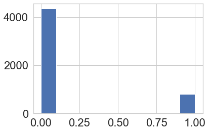

```python
df_base['indicator'].hist();
```

##### Сразу отметим, что есть достаточно большой дизбаланс классов, поэтому некоторые метрики в дальнейшем будем рассматривать предельно внимательно

##### Создаем 2 выборки - тестовую и тренировочную. На них мы будем изначально обучать модель лог.регресии. Таргетом служит наш индикатор, т.е. предсказываем 1 если кризис возможен и 0 если нет причин для кризиса

```python
df_train, df_test = train_test_split(df_base, test_size=0.2, stratify=df['indicator'], random_state = 42)
```

```python
df_test = df_base.drop(df_train.index)
```

```python
y_train = df_train['indicator']
y_test = df_test['indicator']
X_train = df_train.drop('indicator', axis=1)
X_test = df_test.drop('indicator', axis=1)
```

```python
ss = StandardScaler()
X_train_scaled = ss.fit_transform(X_train)
X_test_scaled = ss.transform(X_test)
y_train = np.array(y_train)
```

```python
lr = LogisticRegression()
lr.fit(X_train_scaled, y_train)
y_pred_lr = lr.predict(X_test_scaled)
```

```python
print('Точность классификации:', np.sum(y_test == y_pred_lr) / len(y_test))
```

```
Точность классификации: 0.8527131782945736
```

```python
print('Вес модели:', lr.coef_)
```

```
Вес модели: [[ 1.5622735  -0.83163173 -1.35883721 -1.0052516   1.78008016  1.90738005
   0.11767638 -1.04681942 -0.84507924  0.48537031  0.81769774 -0.39105392]]
```

```python
metrics.precision_score(y_test, y_pred_lr)
```

```
0.5694444444444444
```

```python
metrics.recall_score(y_test, y_pred_lr)
```

```
0.25308641975308643
```

```python
probability_lr = lr.predict_proba(X_test_scaled)
metrics.roc_auc_score(y_test, probability_lr[:, 1])
```

```
0.818724279835391
```

```python
fpr, tpr, treshold = roc_curve(y_test, probability_lr[:, 1])
roc_auc = auc(fpr, tpr)
```

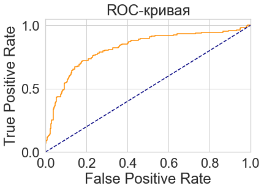

```python
plt.plot(fpr, tpr, color='darkorange')
plt.plot([0, 1], [0, 1], color='navy', linestyle='--')
plt.xlim([0.0, 1.0])
plt.ylim([0.0, 1.05])
plt.xlabel('False Positive Rate')
plt.ylabel('True Positive Rate')
plt.title('ROC-кривая')
plt.show()
```

```python
cf_matrix_lr = confusion_matrix(y_test, y_pred_lr)
print(cf_matrix_lr)
```

```
[[839  31]
 [121  41]]
```

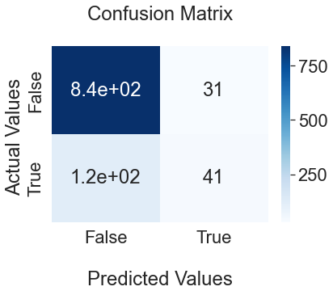

```python
ax = sns.heatmap(cf_matrix_lr, annot=True, cmap='Blues')
ax.set_title('Confusion Matrix\n');
ax.set_xlabel('\nPredicted Values')
ax.set_ylabel('Actual Values ');
ax.xaxis.set_ticklabels(['False','True'])
ax.yaxis.set_ticklabels(['False','True'])
plt.show()
```

##### Результаты не убедительные, так как мы предсказали кризис(когда он действительно был) всего в 41 наблюдении из 162. Очень слабо

##### При этом у нас точность порядка 85%, кажется большой величиной, однако у нас есть тот самый дисбаланс классов, из-за которого могут быть такие результаты

##### Давайте постараемся немного улучшить модель:

# Модифицированная логистическая регрессия

```python
PARAMS = {
    "model__C": np.logspace(-2, 4, 20),
    'model__penalty': ['l1', 'l2'],
    'model__solver': ['newton-cg', 'lbfgs', 'liblinear', 'sag', 'saga']

}
clf = Pipeline(steps=[
    ("model", LogisticRegression(random_state = 42)),
])
grid_search = GridSearchCV(
    estimator=clf,
    param_grid=PARAMS,
    scoring="roc_auc",
    n_jobs=-1,
    cv=10,
)
searcher_lr = grid_search.fit(X_train_scaled, y_train)
```

```python
print(f"best score: {searcher_lr.best_score_}")
print(f"best params: {searcher_lr.best_params_}")
```

```
best score: 0.8326347751154903
best params: {'model__C': 6.951927961775605, 'model__penalty': 'l2', 'model__solver': 'lbfgs'}
```

```python
logreg = searcher_lr.best_estimator_
```

```python
y_pred_logreg = logreg.predict(X_test_scaled)
```

```python
probability_logreg = logreg.predict_proba(X_test_scaled)
metrics.roc_auc_score(y_test, probability[:, 1])
```

[output not shown]

```python
y_pred_logreg = logreg.predict(X_test_scaled)
```

```python
metrics.accuracy_score(y_test, y_pred_logreg)
```

```
0.8565891472868217
```

```python
cf_matrix_logreg = confusion_matrix(y_test, y_pred_logreg)
print(cf_matrix)
```

[output not shown]

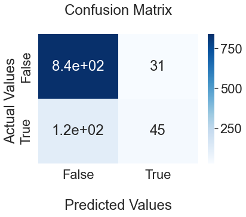

```python
ax = sns.heatmap(cf_matrix_logreg, annot=True, cmap='Blues')
ax.set_title('Confusion Matrix\n');
ax.set_xlabel('\nPredicted Values')
ax.set_ylabel('Actual Values ');
ax.xaxis.set_ticklabels(['False','True'])
ax.yaxis.set_ticklabels(['False','True'])
plt.show()
```

##### Тоже че то не очень, погнали думать дальше

```python
pip install xgboost
```

```python
models = []

models.append(('LR', LogisticRegression(random_state = 42)))
models.append(('LDA', LinearDiscriminantAnalysis()))
models.append(('KNN', KNeighborsClassifier()))
models.append(('CART', DecisionTreeClassifier(random_state = 42)))
models.append(('SVM', SVC(random_state = 42)))
models.append(('XGB', XGBClassifier(random_state = 42)))
models.append(('RF', RandomForestClassifier(random_state = 42)))

#testing models

results = []
names = []
for name, model in models:
    kfold = KFold(n_splits=10)
    cv_results = cross_val_score(model, X_train_scaled, y_train, cv=kfold, scoring='roc_auc')
    results.append(cv_results)
    names.append(name)
    itog_models = '%s: %f (%f)' % (name, cv_results.mean(), cv_results.std())
    print(itog_models)
```

```
LR: 0.830631 (0.024477)
LDA: 0.830495 (0.025549)
KNN: 0.961410 (0.014173)
CART: 0.854854 (0.022403)
SVM: 0.845714 (0.022377)
XGB: 0.973169 (0.010230)
RF: 0.980606 (0.007921)
```

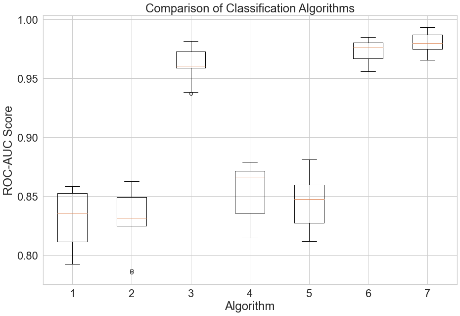

```python
plt.figure(figsize=(15,10))
plt.title('Comparison of Classification Algorithms')
plt.xlabel('Algorithm')
plt.ylabel('ROC-AUC Score')
plt.boxplot(results)
plt.show()
```

# Random forest

```python
from sklearn.model_selection import RandomizedSearchCV
n_estimators = [int(x) for x in np.linspace(start = 100, stop = 1000, num = 10)]
max_features = ['log2', 'sqrt']
max_depth = [int(x) for x in np.linspace(start = 1, stop = 15, num = 15)]
min_samples_split = [int(x) for x in np.linspace(start = 2, stop = 50, num = 10)]
min_samples_leaf = [int(x) for x in np.linspace(start = 2, stop = 50, num = 10)]
bootstrap = [True, False]
param_dist = {'n_estimators': n_estimators,
               'max_features': max_features,
               'max_depth': max_depth,
               'min_samples_split': min_samples_split,
               'min_samples_leaf': min_samples_leaf,
               'bootstrap': bootstrap}
rs = RandomizedSearchCV(RandomForestClassifier(),
                        param_dist,
                        n_iter = 100,
                        cv = 3,
                        scoring="roc_auc",
                        verbose = 1,
                        n_jobs=-1,
                        random_state=0)
rs.fit(X_train_scaled, y_train)
rs.best_params_
```

```
Fitting 3 folds for each of 100 candidates, totalling 300 fits
```

```
{'n_estimators': 700,
 'min_samples_split': 12,
 'min_samples_leaf': 2,
 'max_features': 'sqrt',
 'max_depth': 13,
 'bootstrap': False}
```

```python
rs_df = pd.DataFrame(rs.cv_results_).sort_values('rank_test_score').reset_index(drop=True)
rs_df = rs_df.drop([
            'mean_fit_time',
            'std_fit_time',
            'mean_score_time',
            'std_score_time',
            'params',
            'split0_test_score',
            'split1_test_score',
            'split2_test_score',
            'std_test_score'],
            axis=1)
```

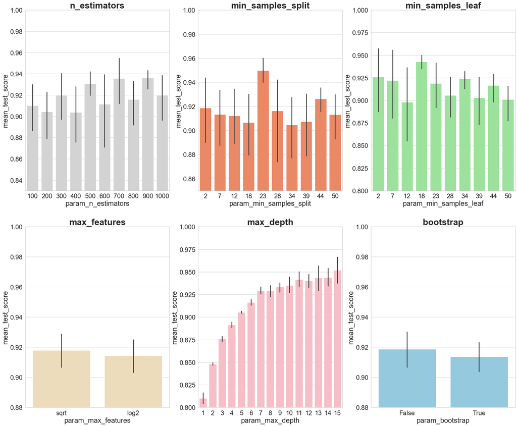

```python
fig, axs = plt.subplots(ncols=3, nrows=2)
sns.set(style="whitegrid", color_codes=True, font_scale = 2)
fig.set_size_inches(30,25)
sns.barplot(x='param_n_estimators', y='mean_test_score', data=rs_df, ax=axs[0,0], color='lightgrey')
axs[0,0].set_ylim([.83,1])
axs[0,0].set_title(label = 'n_estimators', size=30, weight='bold')
sns.barplot(x='param_min_samples_split', y='mean_test_score', data=rs_df, ax=axs[0,1], color='coral')
axs[0,1].set_ylim([.85,1])
axs[0,1].set_title(label = 'min_samples_split', size=30, weight='bold')
sns.barplot(x='param_min_samples_leaf', y='mean_test_score', data=rs_df, ax=axs[0,2], color='lightgreen')
axs[0,2].set_ylim([.80,1])
axs[0,2].set_title(label = 'min_samples_leaf', size=30, weight='bold')
sns.barplot(x='param_max_features', y='mean_test_score', data=rs_df, ax=axs[1,0], color='wheat')
axs[1,0].set_ylim([.88,1])
axs[1,0].set_title(label = 'max_features', size=30, weight='bold')
sns.barplot(x='param_max_depth', y='mean_test_score', data=rs_df, ax=axs[1,1], color='lightpink')
axs[1,1].set_ylim([.80,1])
axs[1,1].set_title(label = 'max_depth', size=30, weight='bold')
sns.barplot(x='param_bootstrap',y='mean_test_score', data=rs_df, ax=axs[1,2], color='skyblue')
axs[1,2].set_ylim([.88,1])
axs[1,2].set_title(label = 'bootstrap', size=30, weight='bold')
plt.show()
```

```python
n_estimators = [500,700,900]
min_samples_split = [2,22,23,24,44]
min_samples_leaf = [2,3,17,18,19,34]
max_features = ['sqrt']
max_depth = [13,14,15]
bootstrap = [False]
param_grid = {'n_estimators': n_estimators,
               'max_features': max_features,
               'max_depth': max_depth,
               'min_samples_split': min_samples_split,
               'min_samples_leaf': min_samples_leaf,
               'bootstrap': bootstrap}
gs = GridSearchCV(RandomForestClassifier(), param_grid, cv = 3, scoring="roc_auc", verbose = 1, n_jobs=-1)
gs.fit(X_train_scaled, y_train)
rfc = gs.best_estimator_
gs.best_params_
```

```
Fitting 3 folds for each of 270 candidates, totalling 810 fits
```

```
{'bootstrap': False,
 'max_depth': 15,
 'max_features': 'sqrt',
 'min_samples_leaf': 2,
 'min_samples_split': 2,
 'n_estimators': 500}
```

```python
y_pred = rfc.predict(X_test_scaled)
```

```python
from sklearn.metrics import confusion_matrix
cf_matrix = confusion_matrix(y_test, y_pred)
print(cf_matrix)
```

```
[[858  12]
 [ 31 131]]
```

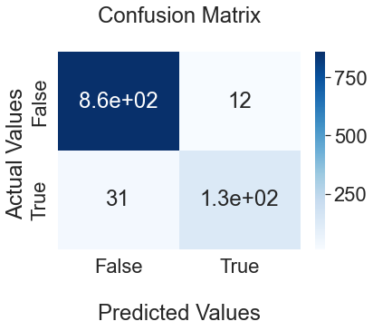

```python
import seaborn as sns
ax = sns.heatmap(cf_matrix, annot=True, cmap='Blues')
ax.set_title('Confusion Matrix\n');
ax.set_xlabel('\nPredicted Values')
ax.set_ylabel('Actual Values ');
ax.xaxis.set_ticklabels(['False','True'])
ax.yaxis.set_ticklabels(['False','True'])
plt.show()
```

##### А вот это уже куда лучше. Мы получили достаточно точную модель, которую можно использовать в дальнейшем для предсказания